# Statistical Tests

Week 4

Published

April 24, 2025

# Before we start

- Questions regarding Lab Assignment or the class?
- clearing environment

```r
iris = iris   # embedded dataset
b = 2

rm(b)
```

[Download script](https://artur-baranov.github.io/nu-ps312-ds/scripts/ps312-d_04.qmd)

[Download data](https://artur-baranov.github.io/nu-ps312-ds/data/vdem_regimes.RDS)

# Agenda

- Wrangling data
- Joining datasets
- Visualizing relationships
- Conducting Statistical Tests

# Exploring Dataset

Today we are working with the subset of V-Dem dataset. For your reference, their codebook is available [here](https://v-dem.net/documents/38/V-Dem_Codebook_v14.pdf).

```r
library(tidyverse)

vdem = readRDS("data/vdem_regimes.RDS")
```

Let’s check the variables included in the data. What does `e_v2x_api` stand for? Check the codebook!

```r
colnames(vdem)
```

```
[1] "country_name" "year"         "e_v2x_api_3C"
```

To simplify the analysis, let’s rename the variable to `regime`, this would help us expedite the process of working with the data!

```r
vdem = vdem %>%
  rename(regime = e_v2x_api_3C)
```

Now, let’s change the `regime` so it’s easier to comprehend. Let’s discuss syntax for a second, pay special attention to `==` and `!=`!. To make the comparison more comprehendable, let’s pretend there are only autocracies and democracies.

```r
vdem = vdem %>%
  mutate(regime_categorical = case_when(regime != 1 ~ "Autocratic",
                                        regime == 1 ~ "Democratic"))
```

Now, make sure everything is labelled correctly! Attention to `useNA = "always"`.

```r
table(vdem$regime_categorical, useNA = "always")
```

```
Autocratic Democratic       <NA>
     20738       5837       1159
```

Now, let’s draw a histogram. Basically, that’s the same information.

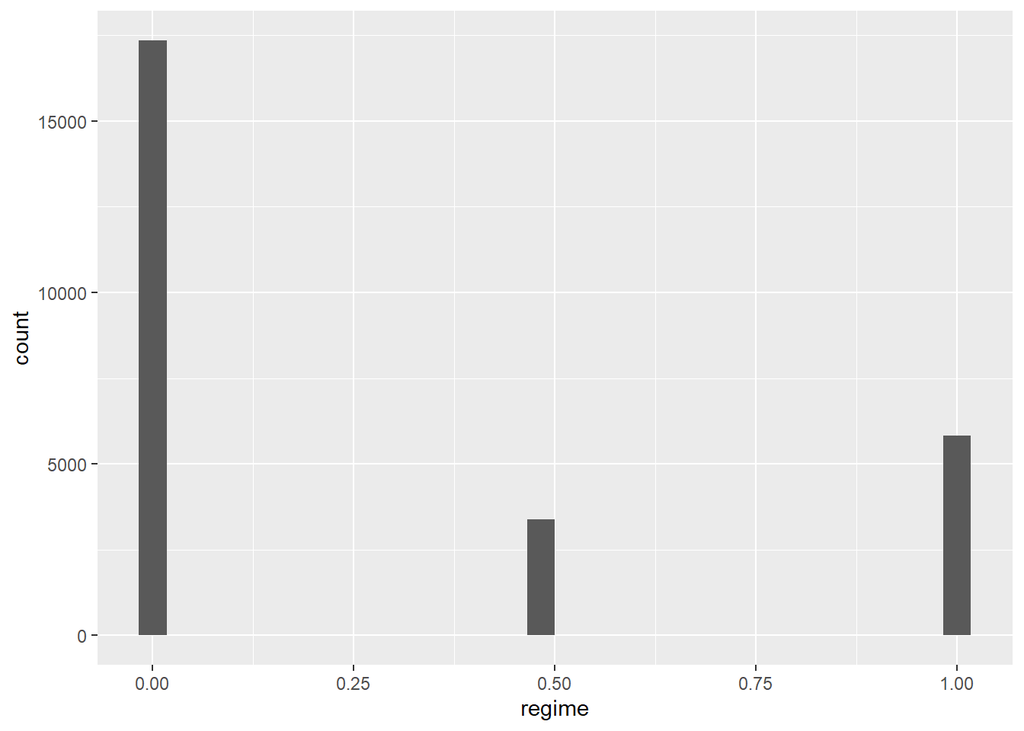

```r
vdem %>%
  ggplot() +
  geom_histogram(aes(x = regime))
```

Now, let’s draw the same variable, but in categorical type of data. Try adding `stat = count` to the previous histogram, too. What does it change? Don’t forget to refresh previous script in mind ([link](https://artur-baranov.github.io/nu-ps312-ds/ps312-d_03.html))!

```r
vdem %>%
  ggplot() +
  geom_histogram(aes(x = regime_categorical), stat = "count")
```

[output not shown]

# Joining data

Imagine, we are asked: are democracies happier than non-democracies?

We can approach answering that with the skills we have! But let’s develop a new one: merging datasets.

First, load the World Happiness Report data. I hope you remember the dataset! But just in case, a short reminder on variables:

- `Country_name` is the name of the country
- `Ladder_score` is the happiness score

```r
whr = read.csv("data/WHR.csv")
```

To merge the data, we need to choose a variable that is common to both datasets. In our case, it’s the country names. Often, you would also have a year variable—but since our WHR report data is for the year 2022, let’s subset the V-Dem data to include only observations from 2022. Once again, why are we using `==`?

```r
vdem_2022 = vdem %>%
  filter(year == 2022)
```

Now, let’s merge the data using `left_join()`. Pay attention to the syntax, especially `by` part.

```r
whr_vdem = whr %>%
  left_join(vdem_2022, by = c("Country_name" = "country_name"))
```

Check the result

```r
whr_vdem %>%
  select(Country_name, Ladder_score, regime, regime_categorical) %>%
  head()
```

```
  Country_name Ladder_score regime regime_categorical
1      Finland        7.804      1         Democratic
2      Denmark        7.586      1         Democratic
3      Iceland        7.530      1         Democratic
4       Israel        7.473      1         Democratic
5  Netherlands        7.403      1         Democratic
6       Sweden        7.395      1         Democratic
```

This is what we did, feel free to explore the [tutorial](https://rpubs.com/williamsurles/293454).

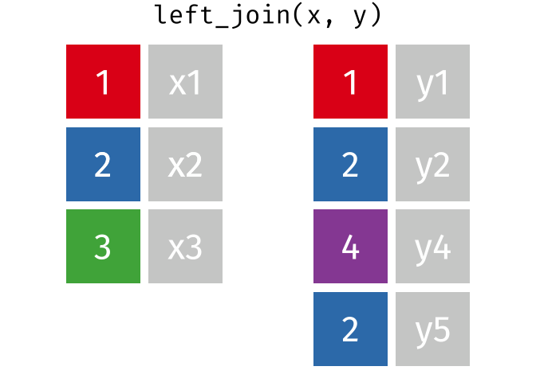

## Analyzing missing data

Now, we likely got a missing values as a result of the merger. The problem might arise due to the different spellings or absence of observation for specific year-country in one of the datasets.

Start with `is.na()` – it checks if there are any missing values. And now, we can easily count if there are any missing values. Everything is here! Makes sense as we used `left_join()` to attach variables to WHR data.

```r
is.na(whr_vdem$Ladder_score) %>%
  sum()
```

```
[1] 0
```

However, the potential missingness might be in the “right” part of the merge, namely the V-Dem data. Let’s check it, too.

```r
is.na(whr_vdem$regime_categorical) %>%
  sum()
```

```
[1] 22
```

Why this might be the case? Let’s explore. Using `mutate()` create an indicator variable for the missing values first. Then, using `filter()` let’s leave only missing values. And finally, using `select()` let’s leave only country names. What these observations have in common?

```r
missing_data = whr_vdem %>%
  mutate(missing = is.na(regime_categorical)) %>% # create indicator variable for missing data
  filter(missing == TRUE) %>%                     # leave only rows with missing regime type
  select(Country_name)                            # choose the Country_name column

missing_data %>%
  head()
```

```
               Country_name
1             United States
2  Taiwan Province of China
3                Kazakhstan
4                   Algeria
5 Hong Kong S.A.R. of China
6       Congo (Brazzaville)
```

Let’s see how these are spelled in the V-Dem data. For example, let’s take how “United States” can be spelled. Using `str_view()` we can identify if the pattern exists in `vdem_2022` dataframe.

```r
str_view(vdem_2022$country_name, "United States")
```

```
[16] │ <United States> of America
```

Now, let’s see why there is no Kazakhstan. It is definitely missing! Probably, it was not yet ranked by V-Dem.

```r
vdem_2022 %>%
  filter(country_name == "Kazakhstan")
```

```
  country_name year regime regime_categorical
1   Kazakhstan 2022     NA               <NA>
```

All in all, these issues related to the most frequent reasons why data might be missing after merging:

- “Key” variables are spelled differently
- The data is not available in one of the datasets

We’ll stick to removing NAs from the dataset using `na.omit()`. Check out tips in the end of the script to dig into other solutions to the problem of missing values.

```r
whr_vdem = whr_vdem %>%
  na.omit()
```

# Visualizing Relationships

Remember, we are asked: are democracies happier than non-democracies? Given the type of data we are working with today, we’ll have categories (regime types) and continuous data (happiness score).

Let’s visualize distribution for `Ladder_score` in `whr_vdem` using `geom_histogram()`. Do you remember how to do this?

**Coding Task**

```r
ggplot(whr_vdem) ...
  ...
```

Ok! A lot of things are going on. First of all, let’s discuss syntax a bit. Remove `position = "identity"` to get the sense of what it stands for. Without this, it would simply draw a histogram, stacking observations on top of each other! Finally, a new argument is `alpha`. It stands for the transparency of the element (bar).

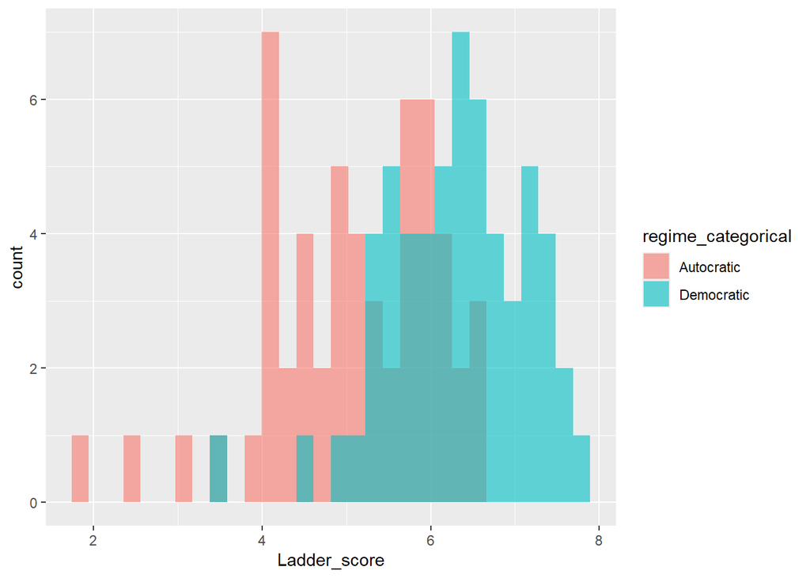

```r
ggplot() +
  geom_histogram(data = whr_vdem, aes(x = Ladder_score, fill = regime_categorical),
                 position = "identity",
                 alpha = 0.6)
```

Now, let’s calculate averages for Democracies and Autocracies.

```r
dem_avg = whr_vdem %>%
  filter(regime_categorical == "Democratic") %>% # leave only Democratic regimes
  summarize(mean = mean(Ladder_score))           # calculate the average

aut_avg = whr_vdem %>%
  filter(regime_categorical == "Autocratic") %>%
  summarize(mean = mean(Ladder_score))
```

And add the averages to the plot.

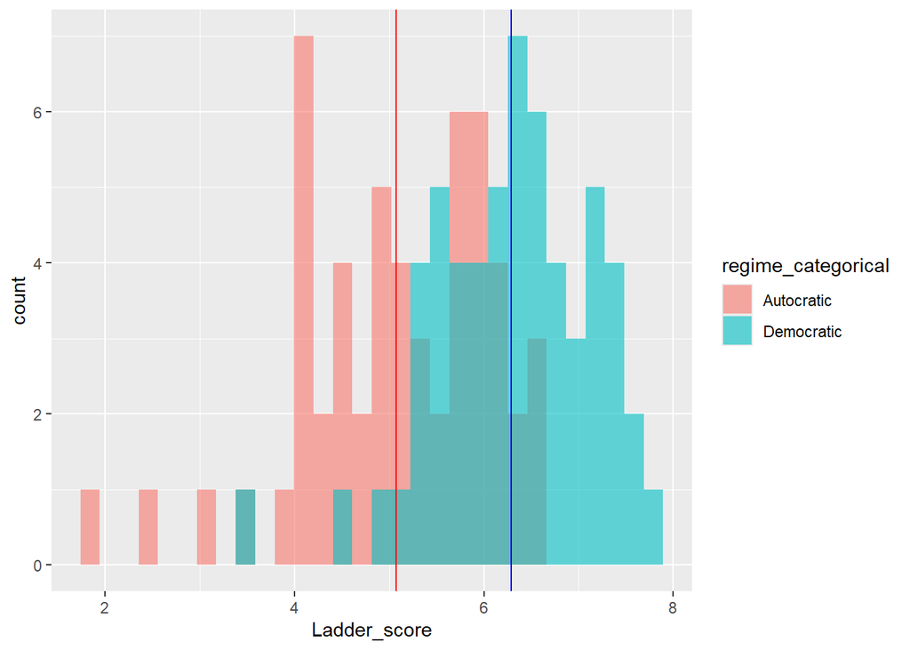

```r
ggplot() +
  geom_histogram(data = whr_vdem, aes(x = Ladder_score, fill = regime_categorical),
                 position = "identity",
                 alpha = 0.6) +
  geom_vline(xintercept = dem_avg$mean, color = "blue") +
  geom_vline(xintercept = aut_avg$mean, color = "red")
```

```r
t.test(whr_vdem$Ladder_score ~ whr_vdem$regime_categorical)
```

```
    Welch Two Sample t-test

data:  whr_vdem$Ladder_score by whr_vdem$regime_categorical
t = -6.8865, df = 104.55, p-value = 4.403e-10
alternative hypothesis: true difference in means between group Autocratic and group Democratic is not equal to 0
95 percent confidence interval:
 -1.5657833 -0.8656675
sample estimates:
mean in group Autocratic mean in group Democratic
                5.074309                 6.290034
```

Does it mean that democracies are happier? Is it a causal relation?

# Additional Practice

Here are some exercises for you to practice what we did today. Investing some time in this would definitely pay off in the long term!

**Coding Task**

In `whr_vdem` dataframe create a variable `Continent_binary` using `mutate()` and `case_when()` on `Continent` to divide observation on `North America` and `Other`.

```r
whr_vdem = whr_vdem ...
  ...(Continent_binary = case_when(Continent == "North America" ... =  "...",
                                      Continent != "..." ~ "Other"))
```

Visualize the distributions. Is it helpful?

```r
ggplot() +
  geom_histogram(data = whr_vdem, aes(x = ... , ... = Continent_binary),
                 position = ...,
                 alpha = 0.6)
```

Calculate and add a a median for “Other” continents to the plot. Customize the plot, add `theme_bw()` and a title!

```r
other_avg = whr_vdem %>%
  filter(Continent == "...") ...
  ...(median = median(Ladder_score))

ggplot() +
  ...(..., aes(x = Ladder_score, fill = Continent_binary),
                 position = "identity",
                 alpha = ...) +
  geom_vline(... = )
```

Perform a `t.test()` to understand if the average Happiness between North America and Other continents are statistically different. Interpret the result

# Some Tips

What to do with the missing data?

- Ignore – a preferable option for the purposes of this class
- Try out `right_join()` or `full_join()`, if applicable.
- If dealing with numeric data, you can insert an average for missing values
- Impute. A bit challenging! But something to study beyond this class

# Check List

I know how clear my environment, and I will do that occasionally

I know how to use `mutate()` and `case_when()` to recode my variables

I know how to identify missing values

I have the intuition behind merging the data, and `left_join()` helps me doing complex stuff

I know how to visualize multiple distributions

I can easily compare distributions using `t.test()` and interpret the result